# WindACR1

Martin Cavarga

5/20/2019

# Methods of Time Series Analysis Applied to Weather Measurements on a Wind Farm

## Introduction

The chosen source of data is a wind farm located in the North Sea (with coords: 54.01433°NL, 6.587667°EL) denoted as LES (1y 2015-01-01 2015-12-31 cfsr) which comes from website http://www.vortexfdc.com/, specifically designed to provide its users with weather data for potential wind farm sites. This specific dataset has been obtained (for free) from year 2015, and contains a variety of measurements, ranging from wind velocity magnitude, through the wind direction angle, temperature up to dimensionless characteristics like the Richardson number “Ri” which corresponds to the ratio of buoyancy over shear flow. In the first 7 parts of this project, I focus on the analysis of a single variable, namely temperature T [°C]. Since the dataset consist of over 47 000 observations of 11 different variables, and thus might be difficult to visualize, I’ve chosen to include only the average temperature measurements for each day.

[figure not shown]

Location of the wind farm

## 1. Visualization and Basic Stats

We begin by extracting the data from a downloaded file

The dataset contains 47808 values, making it too large for our methods. Thus we will choose daily values, namely the average daily temperature. To get the daily data we need to `aggregate` values with the same date:

```
##          day        T
## 1 2015-01-01 6.361594
## 2 2015-01-02 7.925694
## 3 2015-01-03 6.339583
## 4 2015-01-04 6.152083
## 5 2015-01-05 5.435417
## 6 2015-01-06 4.452083
```

Now we can visualize the data as followed:

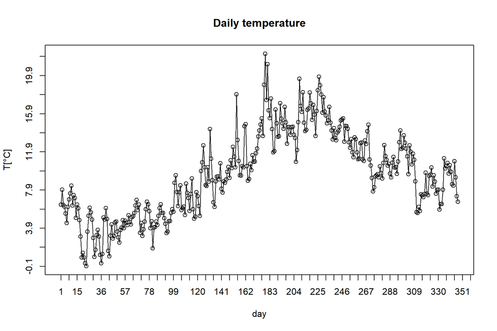

Now we can clearly see the periodic character of the time series which corresponds to the seasonal changes in this latitude. For more details about the particular measurements we might calculate the basic characteristics of the set of values:

```
##        Min.        Max.        Mean      Median    Std.Dev.
## -0.07638889 22.19583333  9.51201195  9.44027778  4.44793929
```

We see that the minimum temperature does not drop far below zero even during the winter, possibly due to warm currents in the northern Atlantic Ocean. Aside from local fluctuations, the same pattern can be expected to appear in the next year, and in the year after that. Perhaps after several decades we might see a change in the annual average temperature due to global warming, for instance.

## 2 Time Series Decomposition: Trend & Seasonal Components

```
##
##  Mann-Kendall Rank Test
##
## data:  temp$T
## statistic = 10.637, n = 347, p-value < 2.2e-16
## alternative hypothesis: trend
```

The only clearly visible systematic components are the periodic seasonal changes due to Earth’s tilt with respect to the Ecliptic plane. Clearly, the most visible cycle will repeat with a period of 365 days. Other fractions of this cycle might be present as well. The remaining cycles can be observed by examining the ACF (Autocorrelation Function) which can be plotted using just the `acf` command:

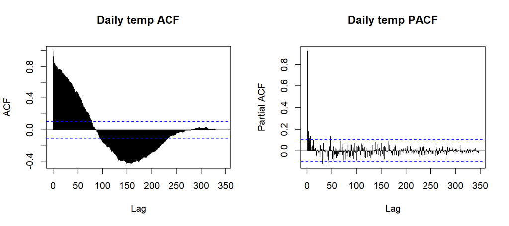

The second plot shows a partial autocorrelation function which also accounts for lags shorter than the given lag $k$, that is: $k-1$ , $k-2$, … , $2$, $1$. With common sense, one deduces that the data already has a 365-day cycle, but from the correlogram we see that other smaller cycles are present in the time series as well. Hence we model the cycles with the following periods

```
##       S1.       S2.        S3        S4
## 365.00000 182.50000  91.25000  30.41667
```

We may assume that there will be a month-long cycles which correspond to the rotation of the Moon, rather than the calendar we use:

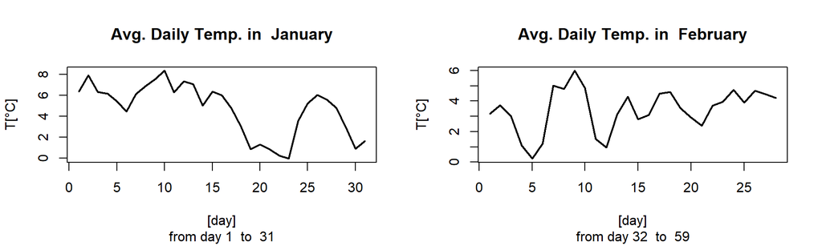

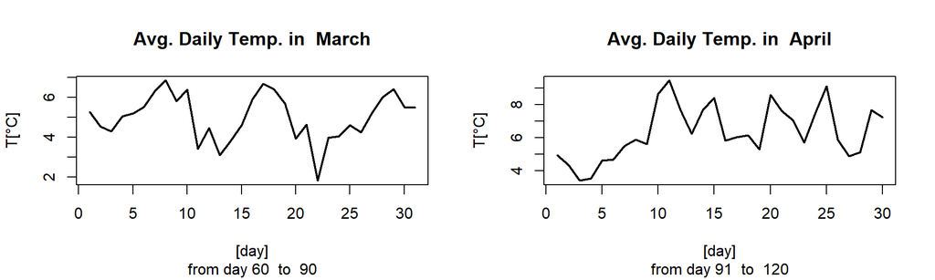

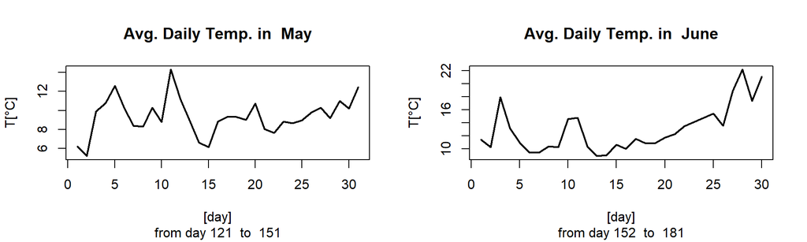

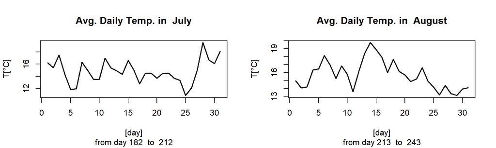

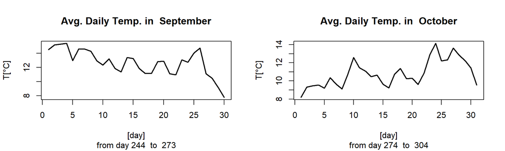

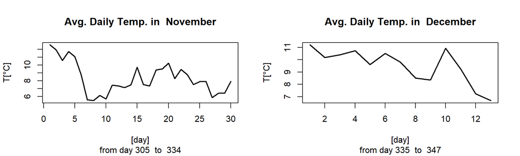

The monthly data do not seem to have a repeating pattern. Hence we will only consider the annual 365-day period.

From now on we will separate our time series into a test part and an evaluation part. All regression analysis will be performed on the test part. Predictions and their quality will be examined on the evaluation part. Generally the test part is taken as the first 80% of the original time series:

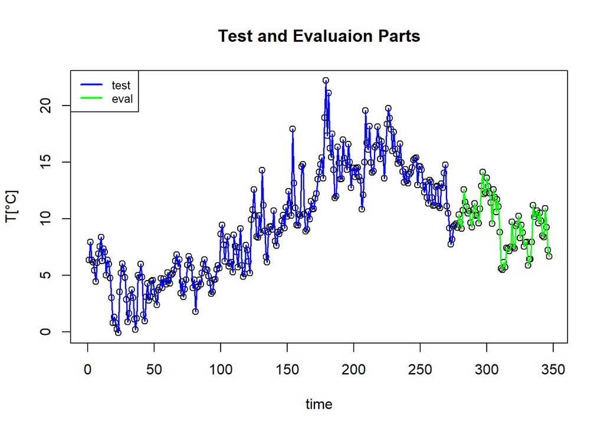

Now we will take the chosen season and regress them against the test part:

```
##
## Call:
## lm(formula = T ~ cos(2 * pi * temp$time/seasons[1]) + sin(2 *
##     pi * temp$time/seasons[1]), data = temp)
##
## Residuals:
##     Min      1Q  Median      3Q     Max
## -5.1399 -1.3827 -0.1335  1.3203  8.7978
##
## Coefficients:
##                                    Estimate Std. Error t value Pr(>|t|)
## (Intercept)                          9.3188     0.1116   83.53   <2e-16
## cos(2 * pi * temp$time/seasons[1])  -4.2990     0.1618  -26.57   <2e-16
## sin(2 * pi * temp$time/seasons[1])  -3.5194     0.1536  -22.91   <2e-16
##
## (Intercept)                        ***
## cos(2 * pi * temp$time/seasons[1]) ***
## sin(2 * pi * temp$time/seasons[1]) ***
## ---
## Signif. codes:  0 '***' 0.001 '**' 0.01 '*' 0.05 '.' 0.1 ' ' 1
##
## Residual standard error: 2.072 on 344 degrees of freedom
## Multiple R-squared:  0.7842, Adjusted R-squared:  0.783
## F-statistic: 625.1 on 2 and 344 DF,  p-value: < 2.2e-16
```

The summary of the regression model shows that amplitudes $C_1 = -4.2990$, $C_2 = -3.5194$, and the intercept: $C_0 = 9.3188$ are significant. And now we can plot the residues after extracting the seasonal components

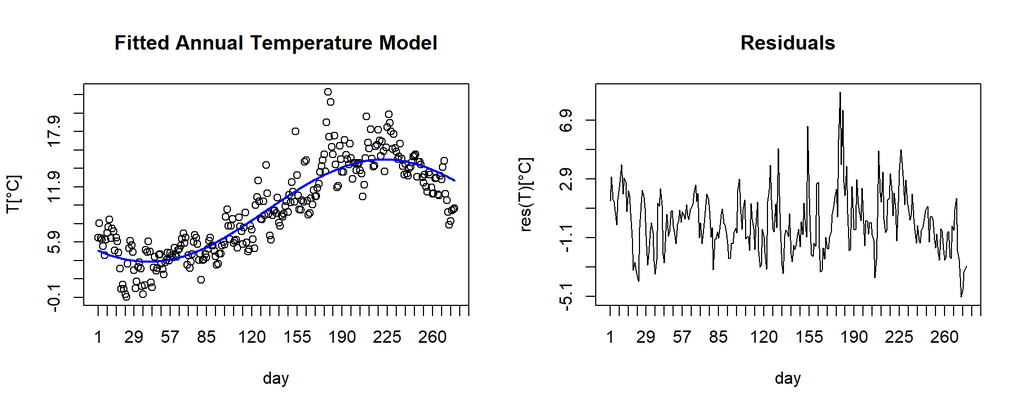

We can see that the residuals after extracting the seasonal components still have not lost some of their periodic behavior.

The resulting regression equation takes the form:

$\hat{x}_t = \hat{C}_0 + \hat{C}_1 \cos{(2 \pi t / 365)} + \hat{C}_2 \sin{(2 \pi t / 365)} + \hat{\varepsilon}_t$

$\hat{x}_t = 9.3188 - 4.2990 \cos{(2 \pi t / 365)} - 3.5194 \sin{(2 \pi t / 365)} + \hat{\varepsilon}_t$

The residuals $\varepsilon_t$ with standard error $\sigma_{\hat{\varepsilon_t}} = 2.072$ may or may not be entirely random. We will have to determine this in the following sections.

We can also include the standard deviations into the coefficients:

$\hat{x}_t = (9.3188 \pm 0.1116) + (-4.2990 \pm 0.1618) \cos{(2 \pi t / 365)} + (-3.5194 \pm 0.1536) \sin{(2 \pi t / 365)}$

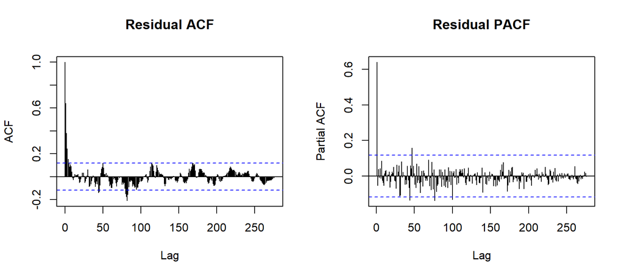

When examining the residual ACF we notice remaining significant correlation for multiple lag values. This is possible due to remaining cyclical components which will be found as significant frequencies after Fourier analysis in the next section.

## 3 Time Series Decomposition: Cyclical Components & Randomness Tests on Residuals

### 3.1 Cyclical Components and Fourier Analysis on Time Series

Now we continue with another step in the decomposition of the original time series. We separate the remaining oscillations via discrete Fourier analysis. A continuous spectrum is generated from the ACF using the following function:

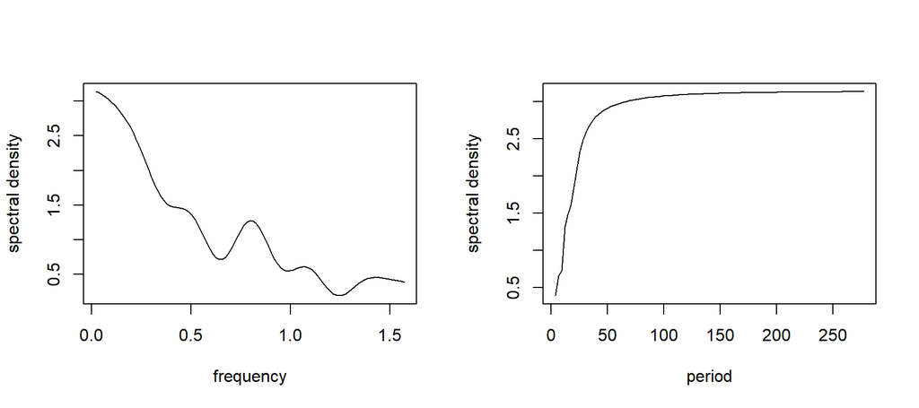

The figure on the right provides a better image of the (continuous) distribution of individual components with periods of oscillation. The hidden frequencies are obtained using discrete Fourier transform (more specifically Fast Fourier Transform):

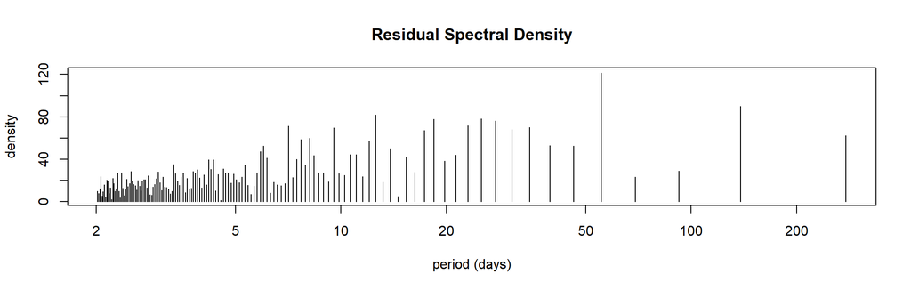

which we can then sort by density, and display the ones with the most weight:

```
##            f      omega     period
## 6  121.50477 0.11341490  55.400000
## 3   90.21367 0.04536596 138.500000
## 23  82.07700 0.49902555  12.590909
## 12  78.23498 0.24951277  25.181818
## 16  77.85140 0.34024469  18.466667
## 11  76.17388 0.22682979  27.700000
## 13  71.71929 0.27219575  23.083333
## 40  71.44612 0.88463620   7.102564
## 9   70.12749 0.18146384  34.625000
## 30  69.83729 0.65780640   9.551724
```

One reliable way to find the most significant frequencies is by using Fischer’s Periodicity Test:

```
## [1] f         omega     period    test.stat crit.val
## <0 rows> (or 0-length row.names)
```

As it appears, Fischer’s Test yields no significant frequency, but since we observe a sequence of significant frequencies that correspond with the ACF shown earlier. Nonetheless, we assume that, say, the first 10 might contribute to the oscillatory behavior of the time series. Thus we take:

```
##            f      omega     period
## 6  121.50477 0.11341490  55.400000
## 3   90.21367 0.04536596 138.500000
## 23  82.07700 0.49902555  12.590909
## 12  78.23498 0.24951277  25.181818
## 16  77.85140 0.34024469  18.466667
## 11  76.17388 0.22682979  27.700000
## 13  71.71929 0.27219575  23.083333
## 40  71.44612 0.88463620   7.102564
## 9   70.12749 0.18146384  34.625000
## 30  69.83729 0.65780640   9.551724
```

which we can then determine more precisely (by finding their local maxima) using the continuous spectral density:

```
##            f      omega     period   omega_sm  period_sm
## 6  121.50477 0.11341490  55.400000 0.10214385  61.513103
## 3   90.21367 0.04536596 138.500000 0.03409491 184.285120
## 23  82.07700 0.49902555  12.590909 0.48775450  12.881860
## 12  78.23498 0.24951277  25.181818 0.23824173  26.373152
## 16  77.85140 0.34024469  18.466667 0.32897365  19.099358
## 11  76.17388 0.22682979  27.700000 0.21555875  29.148366
## 13  71.71929 0.27219575  23.083333 0.26092471  24.080454
## 40  71.44612 0.88463620   7.102564 0.87336515   7.194225
## 9   70.12749 0.18146384  34.625000 0.17019279  36.918046
## 30  69.83729 0.65780640   9.551724 0.66907745   9.390819
```

We can try to complete the regression using the first 3 periods with their fractions, but as it turns out, only the first one with its half is significant.

```
## [1]  61.51310 184.28512  12.88186
```

```
##
## Call:
## lm(formula = Tres ~ cos(2 * pi * temp_test$time/periods[1]) +
##     sin(2 * pi * temp_test$time/periods[1]) + cos(2 * pi * temp_test$time/periods[1] *
##     2) + sin(2 * pi * temp_test$time/periods[1] * 2), data = temp_test)
##
## Residuals:
##     Min      1Q  Median      3Q     Max
## -4.3479 -1.3835 -0.1626  1.1396  8.3554
##
## Coefficients:
##                                             Estimate Std. Error t value
## (Intercept)                                  -0.0222     0.1200  -0.185
## cos(2 * pi * temp_test$time/periods[1])       0.6372     0.1695   3.759
## sin(2 * pi * temp_test$time/periods[1])      -0.2746     0.1699  -1.616
## cos(2 * pi * temp_test$time/periods[1] * 2)   0.2481     0.1689   1.469
## sin(2 * pi * temp_test$time/periods[1] * 2)   0.3601     0.1696   2.123
##                                             Pr(>|t|)
## (Intercept)                                 0.853302
## cos(2 * pi * temp_test$time/periods[1])     0.000209 ***
## sin(2 * pi * temp_test$time/periods[1])     0.107193
## cos(2 * pi * temp_test$time/periods[1] * 2) 0.143106
## sin(2 * pi * temp_test$time/periods[1] * 2) 0.034630 *
## ---
## Signif. codes:  0 '***' 0.001 '**' 0.01 '*' 0.05 '.' 0.1 ' ' 1
##
## Residual standard error: 1.986 on 272 degrees of freedom
## Multiple R-squared:  0.08486,    Adjusted R-squared:  0.07141
## F-statistic: 6.306 on 4 and 272 DF,  p-value: 7.252e-05
```

The cyclical components defined by first two periods seem to be significant, but we cannot be sure if they truly belong into the systematic model. For that reason we will save the residues of this model so that we can compare its predictive properties with only `sCos` in section 5.

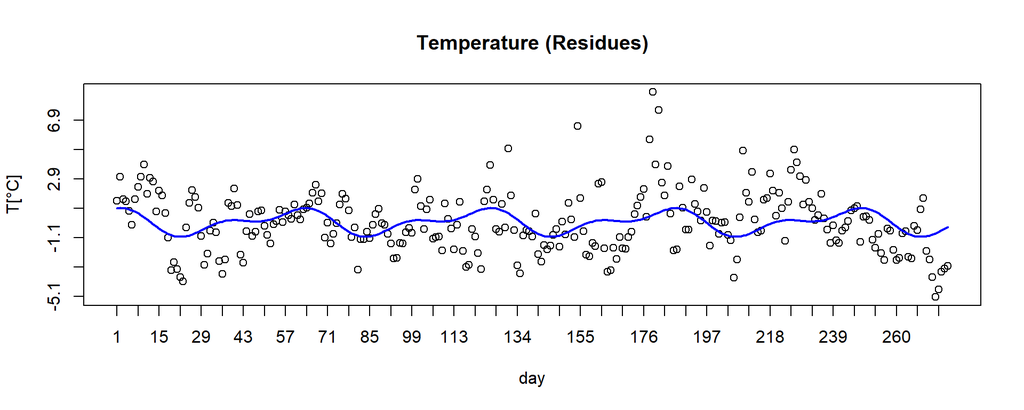

We can combine the seasonal and cyclical components into a single model:

```
##
## Call:
## lm(formula = T ~ cos(2 * pi * temp$time/seasons[1]) + sin(2 *
##     pi * temp$time/seasons[1]) + cos(2 * pi * temp$time/periods[1]) +
##     sin(2 * pi * temp$time/periods[1]) + cos(2 * pi * temp$time/periods[1] *
##     2) + sin(2 * pi * temp$time/periods[1] * 2), data = temp)
##
## Residuals:
##     Min      1Q  Median      3Q     Max
## -4.7813 -1.3168 -0.1271  1.2043  8.2195
##
## Coefficients:
##                                        Estimate Std. Error t value
## (Intercept)                              9.3407     0.1100  84.947
## cos(2 * pi * temp$time/seasons[1])      -4.2549     0.1600 -26.588
## sin(2 * pi * temp$time/seasons[1])      -3.5217     0.1509 -23.344
## cos(2 * pi * temp$time/periods[1])       0.4543     0.1541   2.948
## sin(2 * pi * temp$time/periods[1])      -0.3116     0.1567  -1.988
## cos(2 * pi * temp$time/periods[1] * 2)   0.3072     0.1552   1.980
## sin(2 * pi * temp$time/periods[1] * 2)   0.0891     0.1544   0.577
##                                        Pr(>|t|)
## (Intercept)                             < 2e-16 ***
## cos(2 * pi * temp$time/seasons[1])      < 2e-16 ***
## sin(2 * pi * temp$time/seasons[1])      < 2e-16 ***
## cos(2 * pi * temp$time/periods[1])      0.00342 **
## sin(2 * pi * temp$time/periods[1])      0.04759 *
## cos(2 * pi * temp$time/periods[1] * 2)  0.04854 *
## sin(2 * pi * temp$time/periods[1] * 2)  0.56433
## ---
## Signif. codes:  0 '***' 0.001 '**' 0.01 '*' 0.05 '.' 0.1 ' ' 1
##
## Residual standard error: 2.034 on 340 degrees of freedom
## Multiple R-squared:  0.7945, Adjusted R-squared:  0.7908
## F-statistic:   219 on 6 and 340 DF,  p-value: < 2.2e-16
```

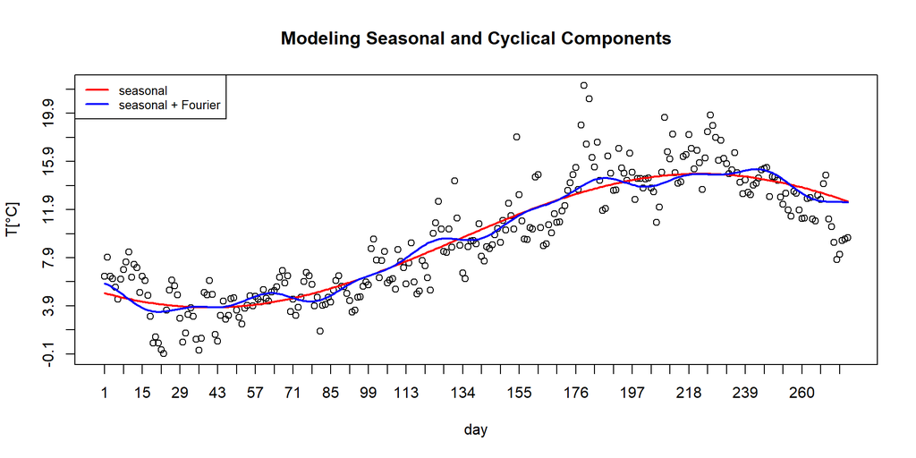

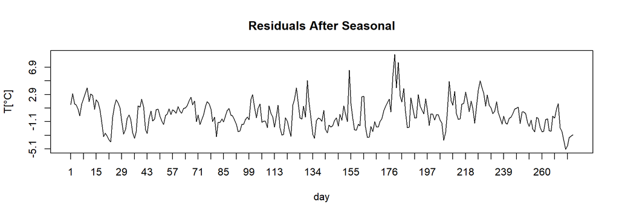

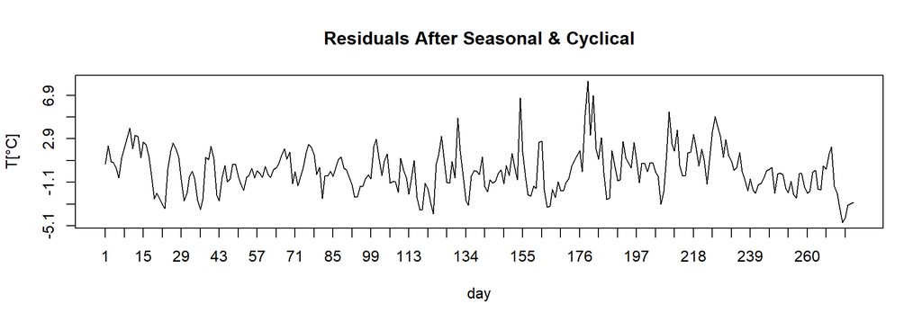

### 3.2 Radomness Tests on Residuals After Extracting Systematic Components

1.) Durbin-Watson autocorrelation test

2.) Zero ACF test

3.) Signed Rank Test

4.) Spearman Rho Test

5.) Turning Point Test

6.) Median Test

We begin by examining the residues after extracting all the systematic components in `model.sCos`, as well as their ACF:

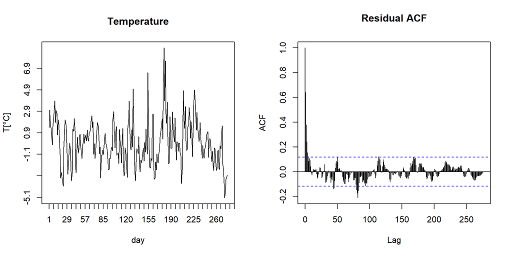

#### 3.2.1 Durbin-Watson Test

The null hypothesis of the D-W test states that the residues of a time series after a least squares regression are uncorrelated, which is put against the alternative hypothesis: that the residuals follow a 1st order autoregressive (AR) process (see section 5.).

We can either use the inbuilt function in the `car` package:

```
## [1] 0.708916
```

or write our own function:

```
## [1] 0.708916
```

The resulting DW statistic is then compared with the D-W critical values for a sample of given size and a number `k` of the terms of linear regression (intercept included), in our case `k = 2` and `size = 277`, hence in a 5% confidence interval:

```
## Alternative Hypothesis: Positive Autocorrelation!
```

We can obtain p-values using the model matrix of the `Scos` model, simulating the stochastic process $Y \sim \rho X - \mu$, computing a DW-statistic for each simulation, and counting the number of `DW < simDW`:

```
## [1] 0
```

```
## [1] 1
```

```
## [1] 0
```

The `rho` parameter appearing in the test is the, so called, autocorrelation coefficient for which $-1 < \rho < 1$ and the null hypothesis translates to verifying that $\rho = 0$ for some confidence interval.

We can model correlation for other lags as well. Aside from the residual vector as an argument, the `durbinWatsonTest` can process the entire regression model. It also has a `max.lag` argument which tells the function which lag to test for when using a model $Y \sim X - L$ (where $L$ is the lag). Parameter `alternative` also tells the function which type of correlation to test for:

```
##  lag Autocorrelation D-W Statistic p-value
##    1     0.675550335     0.6474686   0.000
##    2     0.433682011     1.1245195   0.000
##    3     0.313027183     1.3590661   0.000
##    4     0.223506797     1.5238155   0.000
##    5     0.181083528     1.6062779   0.000
##    6     0.136302455     1.6936098   0.008
##    7     0.137885179     1.6827385   0.000
##    8     0.114853193     1.7162447   0.016
##    9     0.057464236     1.8200715   0.178
##   10    -0.005901538     1.9274691   0.806
##  Alternative hypothesis: rho[lag] != 0
```

```
##  lag Autocorrelation D-W Statistic p-value
##    1     0.675550335     0.6474686   0.000
##    2     0.433682011     1.1245195   0.000
##    3     0.313027183     1.3590661   0.000
##    4     0.223506797     1.5238155   0.000
##    5     0.181083528     1.6062779   0.000
##    6     0.136302455     1.6936098   0.008
##    7     0.137885179     1.6827385   0.010
##    8     0.114853193     1.7162447   0.030
##    9     0.057464236     1.8200715   0.188
##   10    -0.005901538     1.9274691   0.742
##  Alternative hypothesis: rho[lag] != 0
```

```
##  lag Autocorrelation D-W Statistic p-value
##    1     0.675550335     0.6474686   0.000
##    2     0.433682011     1.1245195   0.000
##    3     0.313027183     1.3590661   0.000
##    4     0.223506797     1.5238155   0.000
##    5     0.181083528     1.6062779   0.002
##    6     0.136302455     1.6936098   0.002
##    7     0.137885179     1.6827385   0.008
##    8     0.114853193     1.7162447   0.024
##    9     0.057464236     1.8200715   0.162
##   10    -0.005901538     1.9274691   0.742
##  Alternative hypothesis: rho[lag] != 0
```

We see that DW tests have zero p-value up to lag 4. This means that we could be dealing with an AR process of order 4 or higher.

#### 3.2.2 Zero ACF Test

The test reduces to just finding all the ACF lags k with $ACF(k) > 2/ \sqrt{n}$ where $n$ is the length of the time series.

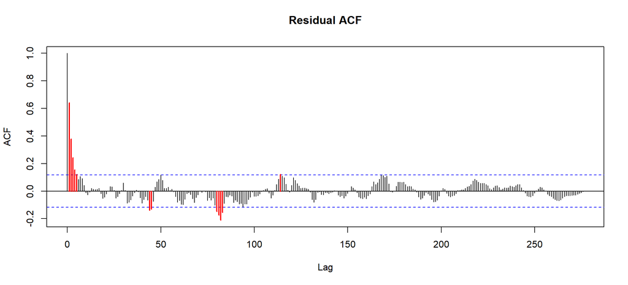

```
##  [1]   1   2   3   4   5  44  45  80  81  82  83 114
```

The result shows that the residual ACF exceeds the zero-value for the lags shown above.

#### 3.2.3 Signed Rank Test

This is a non-parametric test for the presence of a trend in the residual time series, based on the analysis of differences of sets of three consecutive terms. The null hypothesis states that the resulting statistic is asymptotically normally distributed. using a custom approach:

```
## test_stat =  -0.831052033277332  alpha =  0.05  ::: Null Hypothesis! test_stat is normally distributed for n-->infty ! No trend detected.
```

And we can compare the results with an inbuilt function from the `randtests` package:

```
##
##  Difference Sign Test
##
## data:  temp_test$Tres
## statistic = -0.83105, n = 277, p-value = 0.4059
## alternative hypothesis: nonrandomness
```

#### 3.2.4 Spearman Rho Test

Another non-parametric test for the presence of a trend using concordant/discordant pairs of values:

```
## test_stat =  1.57078165417729  alpha =  0.05  ::: Null Hypothesis! test_stat is normally distributed for n-->infty ! No trend detected.
```

using the inbuilt `cor.test`:

```
## [1] -0.09454994
```

```
##
##  Spearman's rank correlation rho
##
## data:  temp_test$time and temp_test$Tres
## S = 3877200, p-value = 0.1164
## alternative hypothesis: true rho is not equal to 0
## sample estimates:
##         rho
## -0.09454994
```

#### 3.2.5 Turning Point Test

This and the following test are both tests for the presence of (previously unfiltered) periodic components in the residual time series. Similarily to the signed rank test, it examines sets of three consecutive terms, except this time looking for so called ‘turning points’, that is: triplets of values in which the middle value is locally extremal (in that triplet). The presence and periodic regularity of turning points implies oscillatory behavior or the residues.

```
## test_stat =  -7.05321906363781  alpha =  0.05  ::: Alternative Hypothesis! Periodic components detected.
```

The p-value of the test can be evaluated for three different hypotheses:

```r
( p_value <- pnorm(test_stat) ) # positive serial correlation
( p_value <- 2*min(p_value, 1 - p_value)) # (two-sided) non-randomness
( p_value <- 1 - p_value ) # negative serial correlation
```

```
##
##  Turning Point Test
##
## data:  temp_test$Tres
## statistic = -7.0532, n = 277, p-value = 8.741e-13
## alternative hypothesis: positive serial correlation
```

```
##
##  Turning Point Test
##
## data:  temp_test$Tres
## statistic = -7.0532, n = 277, p-value = 1.748e-12
## alternative hypothesis: non randomness
```

```
##
##  Turning Point Test
##
## data:  temp_test$Tres
## statistic = -7.0532, n = 277, p-value = 1
## alternative hypothesis: negative serial correlation
```

#### 3.2.6 Median Test

This is another non-parametric test for the presene of periodic components which essentially divides the sample values into distinct groups each of which corresponds to a group of values that are unilaterally above or below the sample median, meaning that if the $i$-th value and its predecessors lie above the median, and the $(i+1)$-th value lies below, for instance, the $(i+1)$-th value is a member of a new group of values which lie below the sample median.

```
##  [1] 1 1 1 1 1 0 1 1 1 1
```

```
## below above
##    34    33
```

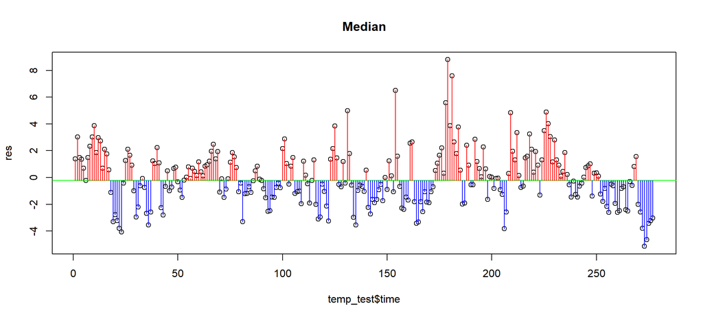

```
## [1] -8.562979
```

```
## qnorm( 0.025 ) <= Zstat || Zstat >= qnorm( 0.975 )
```

```
## -1.96 <= -8.56 >= 1.96
```

```
## Alternative Hypothesis! Non-Randomness ---> Periodicity!
```

```
## [1] 5.499408e-18
```

```
## [1] 1.099882e-17
```

```
## [1] 1
```

```
##
##  Runs Test
##
## data:  U
## statistic = -8.563, runs = 68, n1 = 138, n2 = 138, n = 276,
## p-value < 2.2e-16
## alternative hypothesis: nonrandomness
```

## 4. Introducing ARMA Models and the Hannan-Rissanen Procedure

In general, a stationary (only lag-dependent) stochastic process is determined by p auto-regressive and q moving-average terms. The auto-regressive terms (as by the name) determine the value of the stochastic process at each time from its past values from up to p steps back, and the moving-average terms on the other hand imply dependence on a random process, such as the white noise, for instance, up to q time steps back.

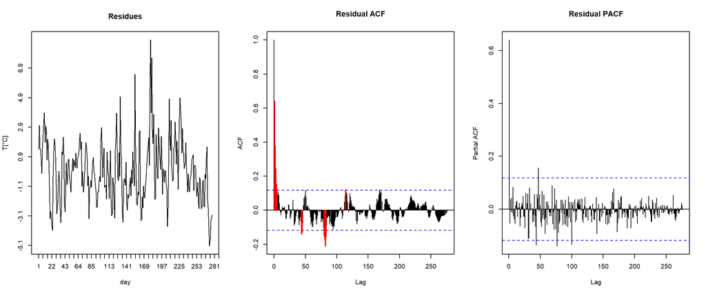

Based on the result of the Durbin-Watson test, the additional oscillations (which can still be seen in red non-zero values of the last residual ACF) should be accounted for by modelling the residues by a suitable $AR(p)$ model (or $ARMA(p,q)$ in general). The process for determining the proper orders $p$ and $q$ of suitable ARMA model candidates is called the Hannan-Rissanen Procedure and it consists of multiple steps.

First, we need to figure out whether the residues need additional transformation, so that they could be properly modelled. For that we test whether: (a) the time series has zero mean value (b) the time series is stationary

```
## [1] -0.04412321
```

So the mean value approximation is close to zero, and the stationarity can be tested using the following test:

```
##
##  Augmented Dickey-Fuller Test
##
## data:  temp_test$Tres
## Dickey-Fuller = -4.1593, Lag order = 6, p-value = 0.99
## alternative hypothesis: explosive
```

According to the Augmented Dickey-Fuller tests the residuals the stationarity hypothesis is rejected. However, since The tests have low statistical power in that they often cannot distinguish between true unit-root processes and near unit-root processes. This is called the “near observation equivalence” problem.

### 4.1. The Hannan-Rissanen Procedure

First, we need to set the maximum values for lag parameters based on the significant lags in residual ACF and PACF. It will be easier to do so in a combined plot:

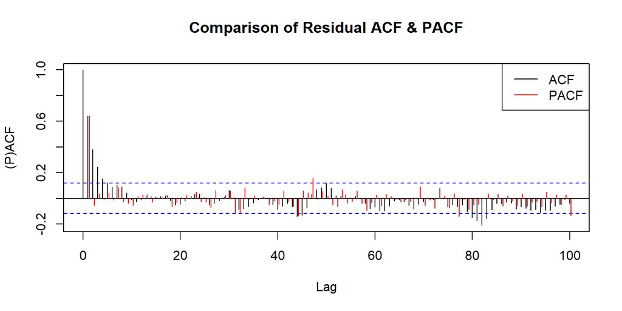

The Yule-Walker method based on solving regression equations against an increasing basis of AR terms can be done through the inbuilt `ar()` function which automatically finds the model with the lowest AIC (Akaike’s Information Criterion). And by plotting the `$aic` parameter we obtain differences $AIC_{min} - AIC_k$ for all models.

```
##            [,1]
## coef 0.64068768
## se   0.04630018
```

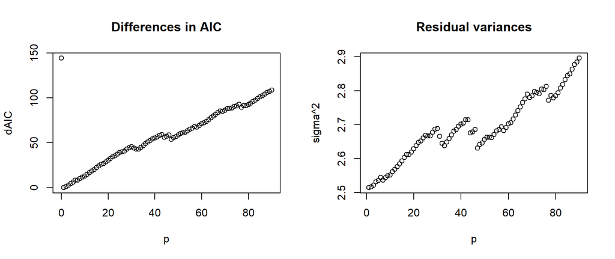

```r
kmax = 20; pmax = 10; qmax = 10;
```

```
##          BIC      AIC
## 1,0 1051.252 1040.391
## 1,2 1056.256 1038.172
## 1,1 1056.484 1042.002
## 2,1 1057.184 1039.100
## 1,3 1058.852 1037.173
```

Now we have 5 ARMA models with the lowest BIC with orders `"p,q"`.

```
##     BIC      AIC      topModels
## 1,0 1051.252 1040.391 List,15
## 1,2 1056.256 1038.172 List,15
## 1,1 1056.484 1042.002 List,15
## 2,1 1057.184 1039.1   List,15
## 1,3 1058.852 1037.173 List,15
```

```
##
## Time series regression with "ts" data:
## Start = 2, End = 277
##
## Call:
## dynlm(formula = x ~ L(x, 1:p), data = tt)
##
## Coefficients:
## (Intercept)    L(x, 1:p)
##    -0.02786      0.64563
```

### 4.2. Adjusting the Regression Coefficients Using the Maximum Likelihood Estimate

The Maximum Likelihood Estimate (MLE) optimizes the, so called, likelihood-function with respect to the regression coefficients. One can find estimates using the Residual Square Sum (RSS). We will optimize the model parameters via an inbuilt function arima, specifying parameter `method = "ML"` and also using the former `dynlm`-type model and directly calculating the RSS.

```
## $`1,0`
##             HannanRissanen_Result MLE_using_ARIMA MLE_not_ARIMA
## (Intercept)           -0.02785883     -0.05406576   -0.02785883
## L(x, 1:p)              0.64562578      0.64440832    0.64562578
##
## $`1,2`
##             HannanRissanen_Result MLE_using_ARIMA MLE_not_ARIMA
## (Intercept)           -0.03309495    -0.054419482   -0.02631937
## L(x, 1:p)              0.69141113     0.669985893    0.68694854
## L(z, 1:q)1            -0.02016805     0.007420686   -0.01196797
## L(z, 1:q)2            -0.09903195    -0.076271207   -0.08960355
##
## $`1,1`
##             HannanRissanen_Result MLE_using_ARIMA MLE_not_ARIMA
## (Intercept)           -0.02911124     -0.05304779   -0.02901350
## L(x, 1:p)              0.61311400      0.59454685    0.60099843
## L(z, 1:q)              0.05785128      0.08460515    0.07659639
##
## $`2,1`
##             HannanRissanen_Result MLE_using_ARIMA MLE_not_ARIMA
## (Intercept)           -0.03399117     -0.05500114   -0.04693901
## L(x, 1:p)1             0.73309498     -0.30089288    0.20292577
## L(x, 1:p)2            -0.08636076      0.58996385    0.25003437
## L(z, 1:q)             -0.06213779      1.00000022    0.48370955
##
## $`1,3`
##             HannanRissanen_Result MLE_using_ARIMA MLE_not_ARIMA
## (Intercept)           -0.02847790    -0.054492828   -0.02487418
## L(x, 1:p)              0.73118840     0.672890578    0.73225467
## L(z, 1:q)1            -0.05992787     0.004427484   -0.05925678
## L(z, 1:q)2            -0.12548876    -0.078290582   -0.12117853
## L(z, 1:q)3            -0.02811048    -0.001503111   -0.02919094
```

```
## (Intercept)   L(x, 1:p)  L(z, 1:q)1  L(z, 1:q)2  L(z, 1:q)3
## -0.02847790  0.73118840 -0.05992787 -0.12548876 -0.02811048
```

```
## (Intercept)   L(x, 1:p)  L(z, 1:q)1  L(z, 1:q)2  L(z, 1:q)3
## -0.02487418  0.73225467 -0.05925678 -0.12117853 -0.02919094
```

### 4.3. Plotting the Resulting Models With their Residuals

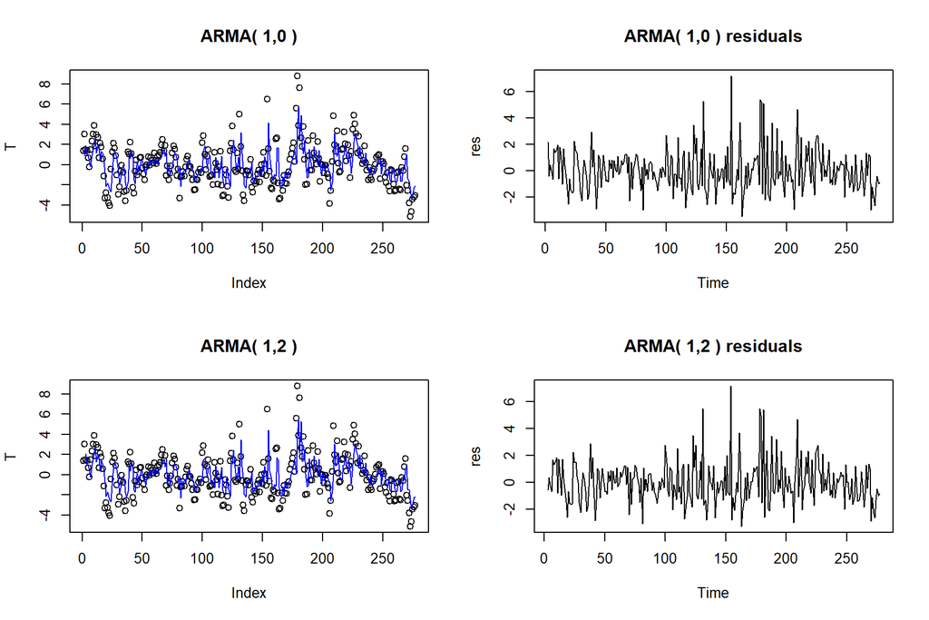

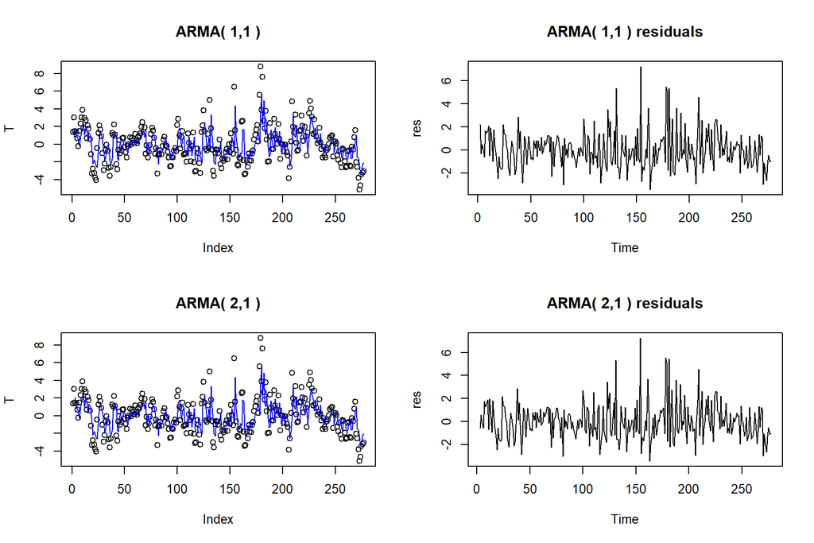

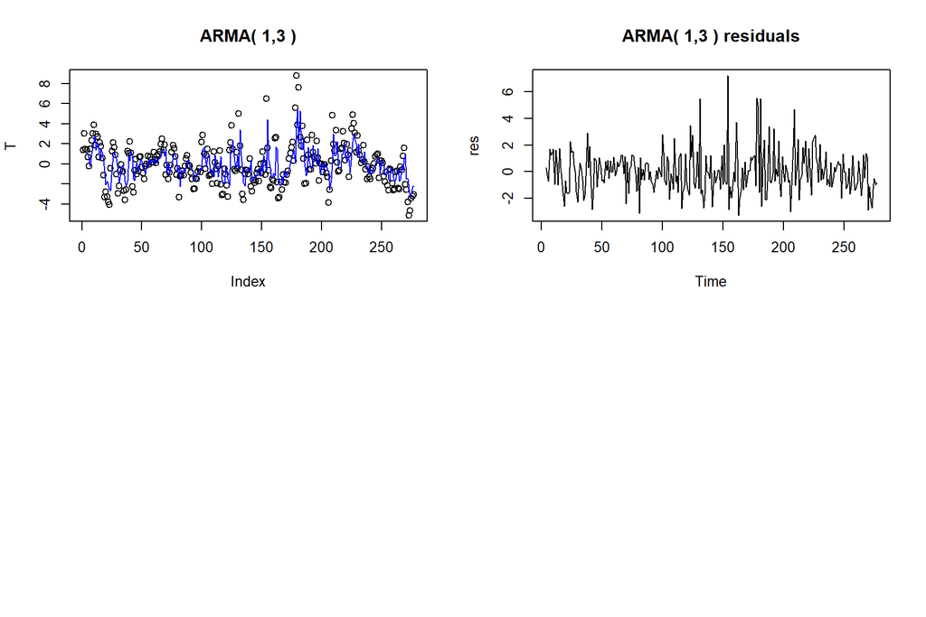

### 4.4. Plotting the Resulting Models In the Original Time Series

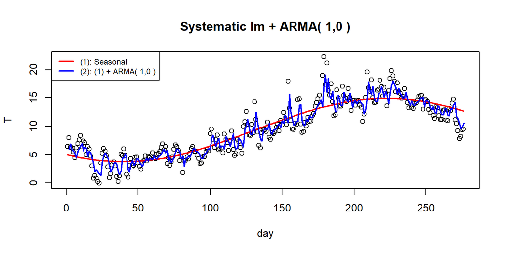

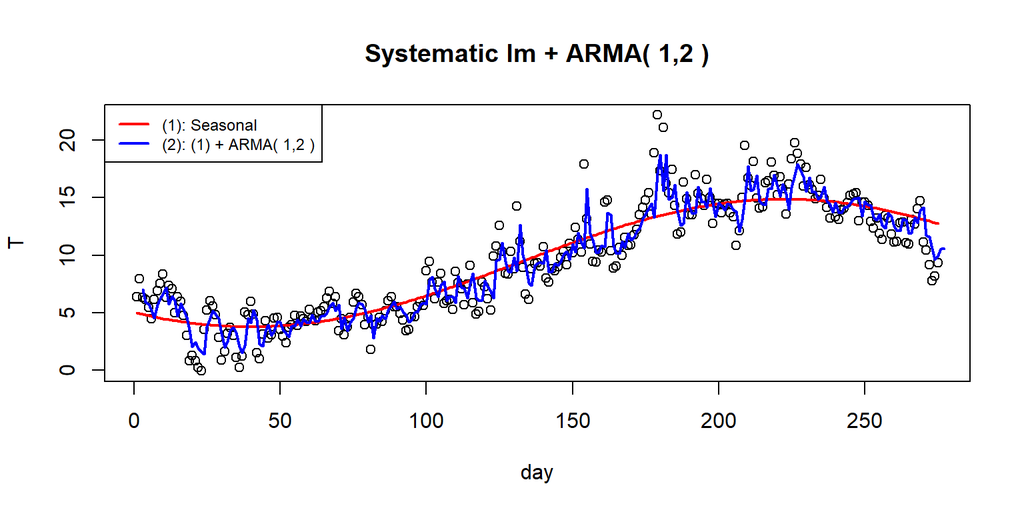

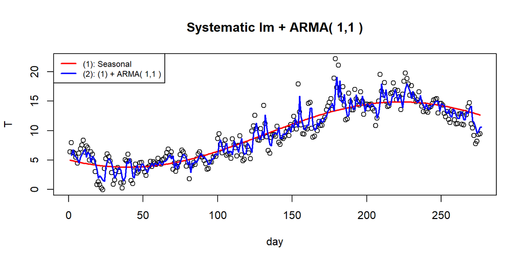

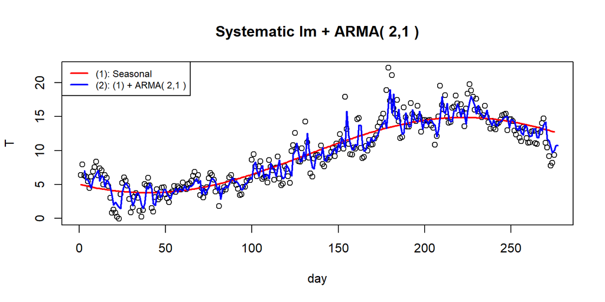

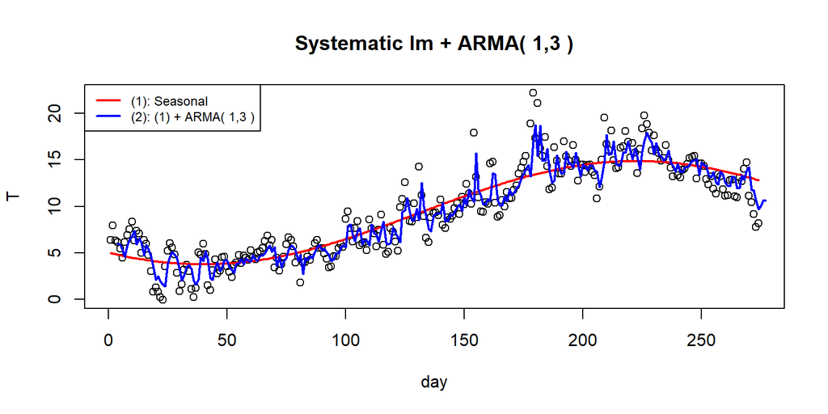

The Hannan-Rissanen procedure with maximum orders: `kmax = 20`, `pmax = 10`, and `qmax = 10`, determined the optimal ARMA models to be:

```
## [1] "1,0" "1,2" "1,1" "2,1" "1,3"
```

Combining the systematic components, i.e.: the seasonal and cyclical components, with the linear regression of a given ARMA model we have found 5 most accurate linear models for the test part of the original time series.  
We can write the resulting regression of an ARMA model:

$\hat{x}_t = \hat{\varphi}_0 + \hat{\varphi}_1 x_{t - 1} + ... + \hat{\varphi}_p x_{t - p} + \hat{\theta}_1 z_{t - 1} + ... + \hat{\theta}_{t - q} z_{t - q} + \hat{\varepsilon}_t$

which corresponds to:

$\hat{x}_t = \hat{\varphi}_0 + \hat{\varphi}_1 x_{t - 1} + \hat{\varepsilon}_t$

$\hat{x}_t = -0.02785883 + 0.64562578 x_{t - 1} + \hat{\varepsilon}_t$,  
$\sigma_{\hat{\varepsilon}_t}^2 = 2.475145$

in case of the very first $ARMA(1,0)$ model, and:

$\hat{x}_t = \hat{\varphi}_0 + \hat{\varphi}_1 x_{t - 1} + \hat{\theta}_1 z_{t - 1} + \hat{\theta}_2 z_{t - 2} + \hat{\varepsilon}_t$

$\hat{x}_t = -0.02631937 + 0.68694854 x_{t - 1} -0.01196797 z_{t - 1} -0.08960355 z_{t - 2} + \hat{\varepsilon}_t + \hat{\varepsilon}_t$,  
$\sigma_{\hat{\varepsilon}_t}^2 = 2.444121$

for the second $ARMA(1,2)$.

For demonstration we will combine the seasonal fit $\hat{x}_t^{S} = \hat{C}_0 + \hat{C}_1 \cos{(2 \pi t / 365)} + \hat{C}_2 \sin{(2 \pi t / 365)}$ with the ARMA fit $\hat{x}_t$ of the first model:

$\hat{x}_t^{S} + \hat{x}_t = \hat{\psi}_0 + \hat{C}_1 \cos{(2 \pi t / 365)} + \hat{C}_2 \sin{(2 \pi t / 365)} + \hat{\varphi}_1 x_{t - 1} + \hat{\varepsilon}_t$,  
$\hat{\psi}_0 = \hat{C}_0 + \hat{\varphi}_0$

$\hat{x}_t^{S} + \hat{x}_t = 9.290926 - 4.2990 \cos{(2 \pi t / 365)} - 3.5194 \sin{(2 \pi t / 365)} + 0.64562578 x_{t - 1} + \hat{\varepsilon}_t$,  
$\sigma_{\hat{\varepsilon}_t}^2 = 2.475145$

The evaluation part will be used in the following section where we will test the given models and carry out predictions.